# Lab 4: Reproducing Sutter, 2009

Simon Halliday

2017 - March - 17

## Loading required packages

Be sure to load the packages you require. We use Hadley Wickham’s “Tidyverse” of packages.

- We need `dplyr` to use `summarise` and `group_by`
- We need `tidyr` for `gather`.
- We also need `ggplot2` for `ggplot`.
- We use panel models, for which we require `plm`.

```r
library(dplyr)
library(tidyr)
library(ggplot2)
library(plm)
```

## Data Import

We now need to import the data. You can download the csv of the file from Google drive here: https://drive.google.com/file/d/0B9jjwkjdUJU7cElvcVI5U3hhdEU/view?usp=sharing.

This .csv is a cleaned up version of the supplementary data provided by Sutter at the AER here: https://www.aeaweb.org/articles?id=10.1257/aer.99.5.2247).

Download the original paper here to make sense of the exercises below: https://drive.google.com/file/d/0B9jjwkjdUJU7eE5MVWRBZktlTm8/view?usp=sharing.

When you call on `read.csv()` or `read_csv()` be sure to include the file extension – .csv – at the end. Notice we use uppercase letters to name the data table we’ve prepared.

```r
SutExp <- read.csv("more/sutterexperiment.csv")
```

## Using rename to have consistent variable names

We want to have consistent naming protocols. So we shall quickly clean the data to make sure that all the variables are consistently labeled with lower case first letters to ensure we don’t confuse them with data tables. To do this, we use the `rename()` command:

```r
SutExp <-
  SutExp %>%
  rename(session = Session, subject = Subject, r1 = R1, r2 = R2, r3 = R3, r4 = R4, r5 = R5, r6 = R6, r7 = R7, r8 = R8, r9 = R9, treatment = Treatment)
```

## summarise and group_by

Now that we have an object with the data in it called `SutExp`, we want a data table that contains the averages for each treatment for each round.

- To find the averages we need to use `group_by` and `summarise`.
- As you can see below, we want to `group_by()` with our Treatment variable (from Sutter’s paper)
- We then need to use `summarise()` to create the *means* of the variable in which we’re interested: R1 through R9 (corresponding to rounds 1 through 9) respectively.
- Notice that I create variables with lower case names to be consistent with our practice of naming variables in lowercase when we can.

```r
groupAves <-
  SutExp %>%
  group_by(treatment) %>%
  summarise(r1 = mean(r1), r2 = mean(r2), r3 = mean(r3), r4 = mean(r4), r5 = mean(r5), r6 = mean(r6), r7 = mean(r7), r8 = mean(r8), r9 = mean(r9))
```

- This is the point at which you will need to make this *wide* data *narrow* before you can turn it into a plot.
- To make the data narrow you will need to use the `gather` command.

Once you have narrowed your data you will then be able to call on `ggplot` to plot the data in a sensible way.

## Narrowing the data:

Now we need narrow data to plot

```r
narrowAve <-
  groupAves %>%
  gather(round, average, r1:r9)
```

And now we can filter this data and put it into a plot.

## Plot 1

We need to filter for individuals and teams, then construct the ggplot.

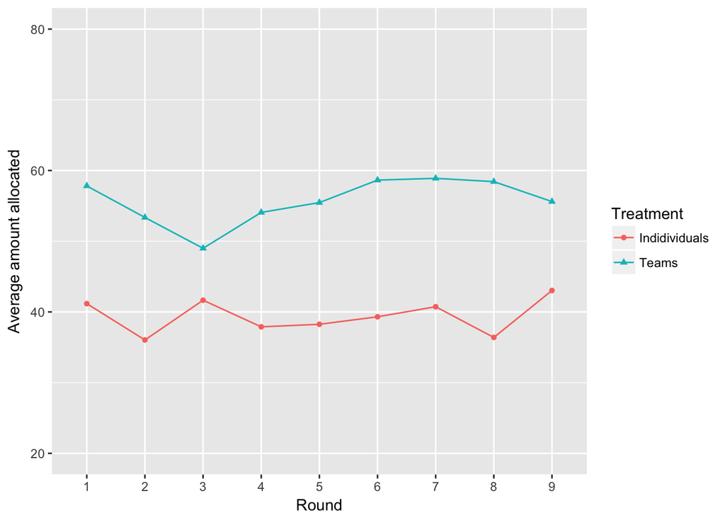

```r
Plot1 <-
  narrowAve %>%
  filter(treatment == "individual" | treatment == "teamtreat" ) %>%
  group_by(treatment) %>%
  arrange(treatment)
Plot1 %>%
  ggplot(aes(x = round, y = average, color = treatment)) +
  geom_point(aes(shape = treatment)) +
  geom_line(aes(group = treatment)) +
  ylim(20, 80) +
  xlab("Round") +
  ylab("Average amount allocated") +
  scale_x_discrete(labels = seq(1, 9, by = 1)) +
  scale_colour_discrete(name = "Treatment",
                         breaks = c("individual", "teamtreat"),
                         labels = c("Indidividuals", "Teams")) +
  scale_shape_discrete(name = "Treatment",
                         breaks = c("individual", "teamtreat"),
                         labels = c("Indidividuals", "Teams"))
```

### The second plot

We need to filter for individuals, paycomm and message, then construct the ggplot.

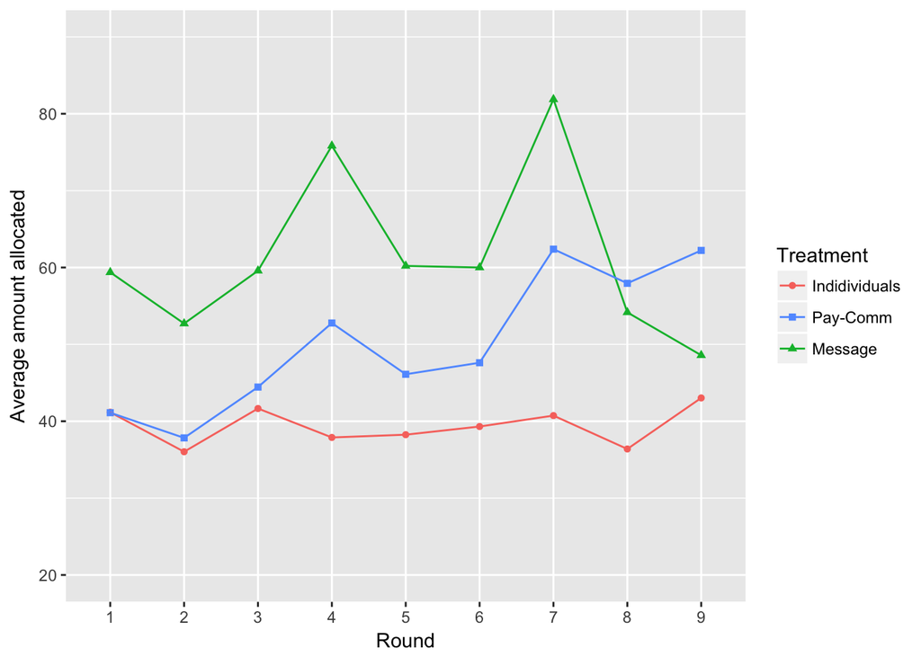

```r
Plot2 <-
  narrowAve %>%
  filter(treatment == "individual" | treatment == "paycomm" |  treatment == "message") %>%
  group_by(treatment) %>%
  arrange(treatment)
Plot2 %>%
  ggplot(aes(x = round, y = average, color = treatment)) +
  geom_point(aes(shape = treatment)) +
  geom_line(aes(group = treatment)) +
  ylim(20, 90) +
  xlab("Round") +
  ylab("Average amount allocated") +
  scale_x_discrete(labels = seq(1, 9, by = 1)) +
  scale_colour_discrete(name = "Treatment",
                         breaks = c("individual", "paycomm", "message"),
                         labels = c("Indidividuals", "Pay-Comm", "Message")) +
  scale_shape_discrete(name = "Treatment",
                         breaks = c("individual", "paycomm", "message"),
                         labels = c("Indidividuals", "Pay-Comm", "Message"))
```

### The third plot

We need to filter for individuals and mixed, then construct the ggplot.

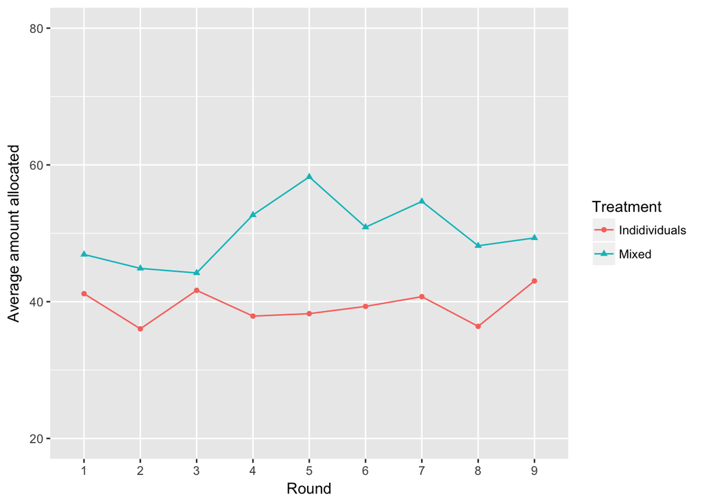

```r
Plot3 <-
  narrowAve %>%
  filter(treatment == "individual" | treatment == "mixed" ) %>%
  group_by(treatment) %>%
  arrange(treatment)
Plot3 %>%
  ggplot(aes(x = round, y = average, color = treatment)) +
  geom_point(aes(shape = treatment)) +
  geom_line(aes(group = treatment)) +
  ylim(20, 80) +
  xlab("Round") +
  ylab("Average amount allocated") +
  scale_x_discrete(labels = seq(1, 9, by = 1)) +
  scale_colour_discrete(name = "Treatment",
                         breaks = c("individual", "mixed"),
                         labels = c("Indidividuals", "Mixed")) +
  scale_shape_discrete(name = "Treatment",
                         breaks = c("individual", "mixed"),
                         labels = c("Indidividuals", "Mixed"))
```

## Reproducing Average Results

We’re now going to go about re-creating the averages that he tests against each other in the paper. To do this, we’re first going to need unique identifiers for each subject. We’ll then look at different methods to find the average and diagnose why one doesn’t work.

We first need to create unique identifiers for each subject so that we don’t get confused.

```r
SutExpUniq <-
  SutExp %>%
  mutate(uniqid = paste(session, treatment, subject, sep = "_"))
head(SutExpUniq)
```

```
##   session subject  r1  r2  r3  r4  r5  r6  r7  r8  r9  treatment team
## 1       1       1   0   0   0   0  10  10   0   0   0 individual   NA
## 2       1       2   0   0  30  40  40   0   0   0  20 individual   NA
## 3       1       3  30  30   0   0   0  60  60  10   0 individual   NA
## 4       1       4  20   0 100   0   0  30  75 100 100 individual   NA
## 5       1       5 100 100 100 100 100 100 100 100 100 individual   NA
## 6       1       6 100 100 100 100 100 100 100   0   0 individual   NA
##           uniqid
## 1 1_individual_1
## 2 1_individual_2
## 3 1_individual_3
## 4 1_individual_4
## 5 1_individual_5
## 6 1_individual_6
```

We need individual averages for round, so we need to `group_by()` with uniqid:

```r
SutUniqAves <-
  SutExpUniq %>%
  group_by(uniqid, treatment) %>%
  summarise(meanval = mean(r1:r9))
```

## Wilcoxon Tests

In the paper, there’s a statistical test that may be unfamiliar to many of you: the Mann-Whitney U-Test. Look up what the Mann-Whitney test is on Google. It is also known as the Wilcoxon Rank Sum test.

- What does the Mann-Whitney test check?
- Why do you think we use it rather than a student’s t-test?

Wilcoxon tests check the differences of samples across a factor variable, such as an experimental treatment. The problem is it only wants *two* levels of that treatment, so we have to filter out the treatments we don’t want to use. We only want “teamtreat” and “individuals” for now.

We could run a Wilcoxon test for the entire sample of the data for subjects for plot 1 and treat the rounds *for each individual* as if they are independent.

First, narrow data from our original SutExp data table:

```r
SutNarrow <-
  SutExpUniq %>%
  gather(round, value, r1:r9) %>%
  arrange(session, subject, treatment, team)
Plot1data <-
  SutNarrow %>%
  filter(treatment == "individual" | treatment == "teamtreat" )
wilcox.test(value ~ treatment, data = Plot1data)
```

```
##
##  Wilcoxon rank sum test with continuity correction
##
## data:  value by treatment
## W = 52876, p-value = 3.838e-10
## alternative hypothesis: true location shift is not equal to 0
```

An alternative might be to find an average for each subject. We’ve already done this with creating the data table `SutUniqAves`. We now filter out the rows we don’t need and run a Wilcoxon (Mann-Whitney) test.

```r
Plot1AveData <-
  SutUniqAves %>%
  filter(treatment == "individual" | treatment == "teamtreat" )
wilcox.test(meanval ~ treatment, data = Plot1AveData)
```

```
##
##  Wilcoxon rank sum test with continuity correction
##
## data:  meanval by treatment
## W = 660, p-value = 0.04532
## alternative hypothesis: true location shift is not equal to 0
```

```r
Plot1Aves <-
  Plot1data %>%
  group_by(uniqid, round) %>%
  summarise(aveval = mean(value))
```

We now want to run a regression using value as the dependent variable (LHS) and each of the treatments as a dummy variable.

```r
m1 <- lm(value ~ treatment, data = SutNarrow)
summary(m1)
```

```
##
## Call:
## lm(formula = value ~ treatment, data = SutNarrow)
##
## Residuals:
##     Min      1Q  Median      3Q     Max
## -61.370 -29.385  -0.542  38.630  60.615
##
## Coefficients:
##                    Estimate Std. Error t value Pr(>|t|)
## (Intercept)          39.385      1.451  27.152  < 2e-16 ***
## treatmentmessage     21.985      1.994  11.028  < 2e-16 ***
## treatmentmixed       10.609      1.925   5.510 3.92e-08 ***
## treatmentpaycomm     10.886      2.144   5.077 4.09e-07 ***
## treatmentteamtreat   16.313      2.629   6.204 6.34e-10 ***
## ---
## Signif. codes:  0 '***' 0.001 '**' 0.01 '*' 0.05 '.' 0.1 ' ' 1
##
## Residual standard error: 34.81 on 2713 degrees of freedom
## Multiple R-squared:  0.04473,    Adjusted R-squared:  0.04333
## F-statistic: 31.76 on 4 and 2713 DF,  p-value: < 2.2e-16
```

The first command assigns to “m1” a linear model (using the `lm()` function) where value is a function of treatment. Treatment is a “factor”, so R automatically converts the different components of the factor into dummy variables in a linear regression.

We need to do this as a panel regression. Here’s one way of doing it using the `plm` package.

```r
m2 <- plm(value ~ treatment, data = SutNarrow, index = c("uniqid"), model = "pooling")
summary(m2)
```

```
## Oneway (individual) effect Pooling Model
##
## Call:
## plm(formula = value ~ treatment, data = SutNarrow, model = "pooling",
##     index = c("uniqid"))
##
## Balanced Panel: n=302, T=9, N=2718
##
## Residuals :
##    Min. 1st Qu.  Median 3rd Qu.    Max.
## -61.400 -29.400  -0.542  38.600  60.600
##
## Coefficients :
##                    Estimate Std. Error t-value  Pr(>|t|)
## (Intercept)         39.3854     1.4505 27.1523 < 2.2e-16 ***
## treatmentmessage    21.9850     1.9936 11.0279 < 2.2e-16 ***
## treatmentmixed      10.6093     1.9254  5.5102 3.921e-08 ***
## treatmentpaycomm    10.8862     2.1442  5.0770 4.095e-07 ***
## treatmentteamtreat  16.3130     2.6293  6.2043 6.335e-10 ***
## ---
## Signif. codes:  0 '***' 0.001 '**' 0.01 '*' 0.05 '.' 0.1 ' ' 1
##
## Total Sum of Squares:    3441900
## Residual Sum of Squares: 3288000
## R-Squared:      0.044734
## Adj. R-Squared: 0.044652
## F-statistic: 31.7615 on 4 and 2713 DF, p-value: < 2.22e-16
```

And another similar way of doing it with the same package:

```r
m3 <- plm(value ~ treatment, data = SutNarrow, index = c("uniqid"), model = "random", effect = "time")
summary(m3)
```

```
## Oneway (time) effect Random Effect Model
##    (Swamy-Arora's transformation)
##
## Call:
## plm(formula = value ~ treatment, data = SutNarrow, effect = "time",
##     model = "random", index = c("uniqid"))
##
## Balanced Panel: n=302, T=9, N=2718
##
## Effects:
##                    var  std.dev share
## idiosyncratic 1197.631   34.607 0.985
## time            18.044    4.248 0.015
## theta:  0.5755
##
## Residuals :
##    Min. 1st Qu.  Median 3rd Qu.    Max.
##  -62.00  -28.60   -2.67   33.80   64.40
##
## Coefficients :
##                    Estimate Std. Error t-value  Pr(>|t|)
## (Intercept)         39.3854     2.0207 19.4914 < 2.2e-16 ***
## treatmentmessage    21.9850     1.9815 11.0951 < 2.2e-16 ***
## treatmentmixed      10.6093     1.9137  5.5437 3.246e-08 ***
## treatmentpaycomm    10.8862     2.1313  5.1079 3.484e-07 ***
## treatmentteamtreat  16.3130     2.6134  6.2420 4.996e-10 ***
## ---
## Signif. codes:  0 '***' 0.001 '**' 0.01 '*' 0.05 '.' 0.1 ' ' 1
##
## Total Sum of Squares:    3402300
## Residual Sum of Squares: 3248300
## R-Squared:      0.045255
## Adj. R-Squared: 0.045172
## F-statistic: 32.1494 on 4 and 2713 DF, p-value: < 2.22e-16
```